# Simulating clinical trials

Steve Simon

March 22, 2017

## Part 5. Hedging priors

One problem with informative prior distributions is that many researchers get them wrong. They are either too optimistic about the accrual rate, or they think they know the accrual rate with more certainty than they actually do, or sometimes both.

You can minimize the problems associated with a bad informative prior by adding a hedging hyperparameter.

### Here’s the code for a hedging hpyerparameter.

```
## data {
##   int<lower=1>           N; // planned number of patients
##   int<lower=0>           n; // observed patients
##   real<lower=0, upper=1> S; // strength of prior
##   real<lower=0>          T; // planned duration of trial
##   real<lower=0>          t; // observed time
## }
## parameters {
##   real<lower=0> lambda;
##   real<lower=0, upper=2> pi; // hedging hyperprior
## }
## model {
##   pi ~ uniform(0, 2);
##   lambda ~ gamma(1+pi*(N*S-1), T/N+pi*(T*S-T/N));
##   if (t>0) n ~ poisson(t*lambda);
## }
## generated quantities {
##   real<lower=0> Nstar;
##   Nstar = n + poisson_rng((T-t)*lambda);
## }
```

### Figure 5.1. Comparison of simple and hedged predictions prior to data collection.

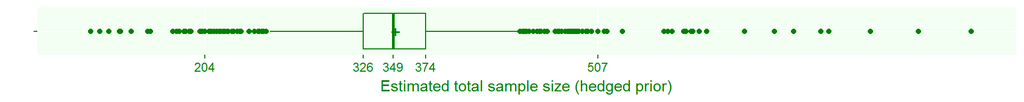

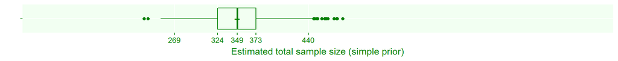

The hedging hyperprior creates a mixture of gamma priors from weak to strong. So it is going to produce more variable predictions than a simple gamma prior.

### Figure 5.2. Updated prediction with a hedged prior.

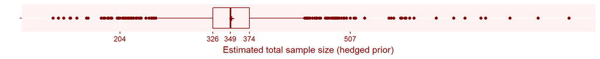

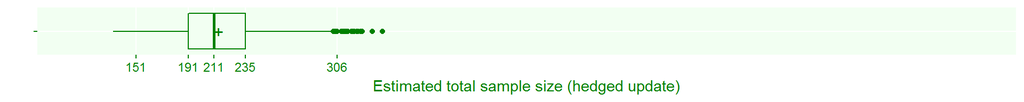

The update with the hedging hyperprior ends up downweighting the strength of the prior distribution, so the weighted average of the data and the prior is weighted very heavily towards the data.

### Figure 5.3. Updated prediction with a simple prior.

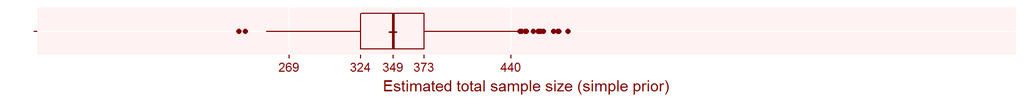

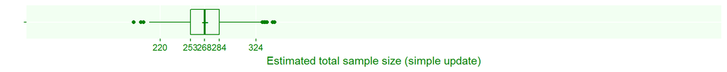

In contrast, because the simple prior was very strong, the weighted average of the prior and the data is pulled back towards the prior.

### Figure 5.4. Updated prediction with a flat prior.

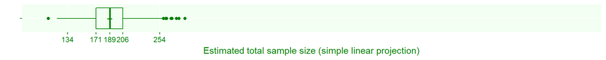

The flat prior behaves as you would suspect, putting pretty much all of the weight on the data.

### Figure 5.5. Updated distribution of hedging hyperparameter.

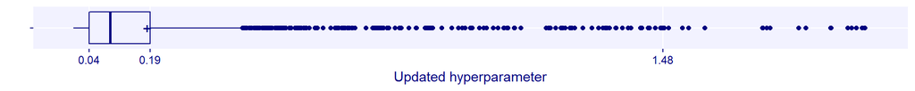

The distribution of the hyperparameter shows that when the data and the prior distribution disagree, the hyperparameter shrinks towards zero, effectively weakening the prior.

### Alternative scenario

Consider an alternative scenario, where the prior distribution and the actual accrual data are in close agreement. This might occur if the time to recruit 41 patients was 129 days instead of 239 days. This is an observed accrual rate of 9.5 patients per month which is very close to the prior estimate of accrual rate of 9.6 patients per month.

### Figure 5.6. Alternative update with a hedged prior.

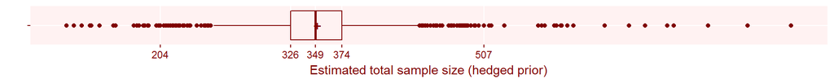

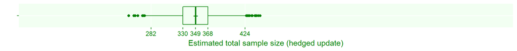

The heding hyperprior does not need to downweight the strong prior when the data and the prior as in such close agreement.

### Figure 5.7. Alternative update prediction with a simple prior.

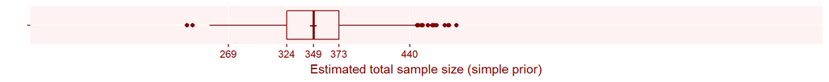

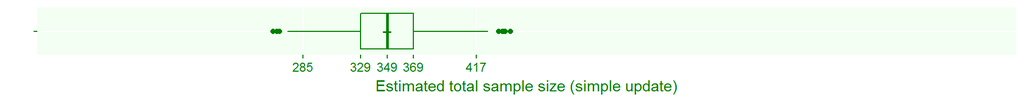

The predicted sample size of the simple prior is very similar to the hedging hyperprior when you have such good agreement.

### Figure 5.8. Alternative update with a flat prior.

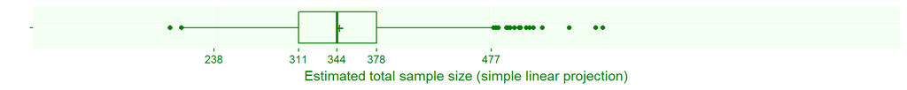

The flat prior also is close to the observed accrual rate, but because it does not add the precision of the prior to the precision of the data, you see much more variation in the predicted total sample size.

### Figure 5.9. Alternative update of hedging hyperparameter.

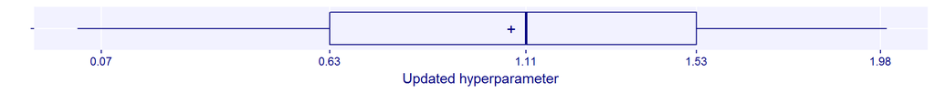